# Bayesian GLMM Part10

# 8 Fit the model

**brms**

**Using default priors**

In `brms`, the default priors are designed to be weakly informative. They are chosen to provide moderate regularisation (to help prevent over fitting) and help stabilise the computations.

Unlike `rstanarm`, `brms` models must be compiled before they start sampling. For most models, the compilation of the stan code takes around 45 seconds.

```r
ltmp_sub.form <- bf(
    n.points | trials(total.points) ~ fREPORT_YEAR +
        (1 | REEF_SITE) + (1 | REEF_SITE_TRANSECT),
    family = binomial(link = "logit")
)
options(width=150)
ltmp_sub.form %>% get_prior(data = ltmp_sub)
```

```
                prior     class             coef              group resp dpar nlpar lb ub       source
               (flat)         b                                                                default
               (flat)         b fREPORT_YEAR1995                                          (vectorized)
               (flat)         b fREPORT_YEAR1996                                          (vectorized)
               (flat)         b fREPORT_YEAR1997                                          (vectorized)
               (flat)         b fREPORT_YEAR1998                                          (vectorized)
               (flat)         b fREPORT_YEAR1999                                          (vectorized)
               (flat)         b fREPORT_YEAR2000                                          (vectorized)
               (flat)         b fREPORT_YEAR2001                                          (vectorized)
               (flat)         b fREPORT_YEAR2002                                          (vectorized)
               (flat)         b fREPORT_YEAR2003                                          (vectorized)
               (flat)         b fREPORT_YEAR2004                                          (vectorized)
               (flat)         b fREPORT_YEAR2005                                          (vectorized)
               (flat)         b fREPORT_YEAR2006                                          (vectorized)
               (flat)         b fREPORT_YEAR2007                                          (vectorized)
               (flat)         b fREPORT_YEAR2008                                          (vectorized)
               (flat)         b fREPORT_YEAR2009                                          (vectorized)
               (flat)         b fREPORT_YEAR2010                                          (vectorized)
               (flat)         b fREPORT_YEAR2011                                          (vectorized)
               (flat)         b fREPORT_YEAR2012                                          (vectorized)
               (flat)         b fREPORT_YEAR2013                                          (vectorized)
               (flat)         b fREPORT_YEAR2014                                          (vectorized)
               (flat)         b fREPORT_YEAR2015                                          (vectorized)
               (flat)         b fREPORT_YEAR2016                                          (vectorized)
               (flat)         b fREPORT_YEAR2017                                          (vectorized)
               (flat)         b fREPORT_YEAR2018                                          (vectorized)
               (flat)         b fREPORT_YEAR2019                                          (vectorized)
               (flat)         b fREPORT_YEAR2020                                          (vectorized)
               (flat)         b fREPORT_YEAR2021                                          (vectorized)
 student_t(3, 0, 2.5) Intercept                                                                default
 student_t(3, 0, 2.5)        sd                                                      0         default
 student_t(3, 0, 2.5)        sd                           REEF_SITE                  0    (vectorized)
 student_t(3, 0, 2.5)        sd        Intercept          REEF_SITE                  0    (vectorized)
 student_t(3, 0, 2.5)        sd                  REEF_SITE_TRANSECT                  0    (vectorized)
 student_t(3, 0, 2.5)        sd        Intercept REEF_SITE_TRANSECT                  0    (vectorized)
```

```r
options(width=80)
```

**Defining priors**

The following link provides some guidance about defining priors. [https://github.com/stan-dev/stan/wiki/Prior-Choice-Recommendations]

When defining our own priors, we typically do not want them to be scaled.

If we wanted to define our own priors that were less vague, yet still not likely to bias the outcomes, we could try the following priors (mainly plucked out of thin air):

Note, for hierarchical models, the model will tend to want to have a large $sigma$ in order to fit the data better. It is a good idea to **regularise** this tendency by applying a prior that has most mass around zero. Suitable candidates include:

- half-t: as the degrees of freedom approach infinity, this will approach a half-normal
- half-cauchy: this is essentially a half-t with 1 degree of freedom
- exponential

I will also overlay the raw data for comparison.

```r
ltmp_sub |>
  group_by(fREPORT_YEAR) |>
  summarise(
    Median = median(qlogis(n.points / total.points)),
    MAD = mad(qlogis(n.points / total.points)),
    N = mean(total.points)
  )
```

```
# A tibble: 28 × 4
   fREPORT_YEAR Median   MAD     N
   <fct>         <dbl> <dbl> <dbl>
 1 2023         -0.758 0.303  202.
 2 2021         -1.19  0.284  201.
 3 2020         -1.30  0.291  201.
 4 2019         -1.63  0.236  201.
 5 2018         -1.99  0.263  200
 6 2017         -2.09  0.242  200
 7 2016         -1.15  0.246  200.
 8 2015         -1.42  0.352  200
 9 2014         -1.66  0.295  200
10 2013         -1.90  0.360  200
# ℹ 18 more rows
```

```r
priors <- prior(normal(-0.7, 0.3), class = "Intercept") +
  prior(normal(0, 2), class = "b") +
  prior(student_t(3, 0, 0.5), class = "sd")
ltmp_sub.form <- bf(
  n.points | trials(total.points) ~ fREPORT_YEAR +
    (1 | REEF_SITE) + (1 | REEF_SITE_TRANSECT),
  family = binomial(link = "logit")
)
ltmp_sub.brm2 <- brm(ltmp_sub.form,
  data = ltmp_sub,
  prior = priors,
  sample_prior = "only",
  iter = 10000,
  warmup = 5000,
  chains = 3, cores = 3,
  thin = 10,
  refresh = 0,
  control = list(adapt_delta = 0.99, max_treedepth = 20),
  backend = "rstan"
)
```

```
Setting all 'trials' variables to 1 by default if not specified otherwise.
```

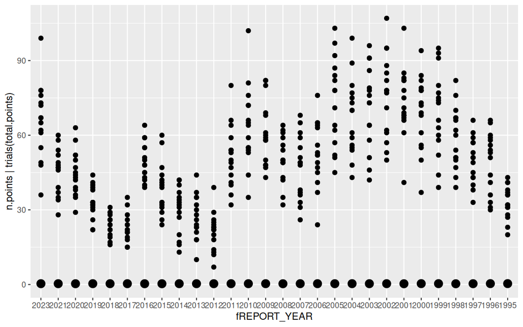

```r
ltmp_sub.brm2 |>
  conditional_effects() |>
  plot(points = TRUE)
```

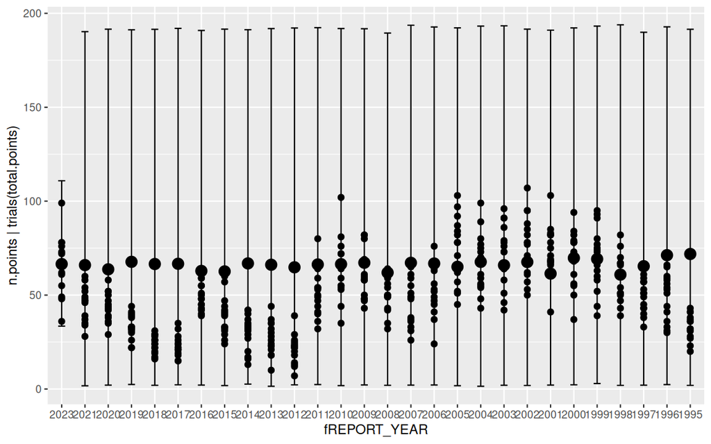

```r
ltmp_sub.brm2 |>
  conditional_effects(conditions = data.frame(total.points = 200)) |>
  plot(points = TRUE)
```

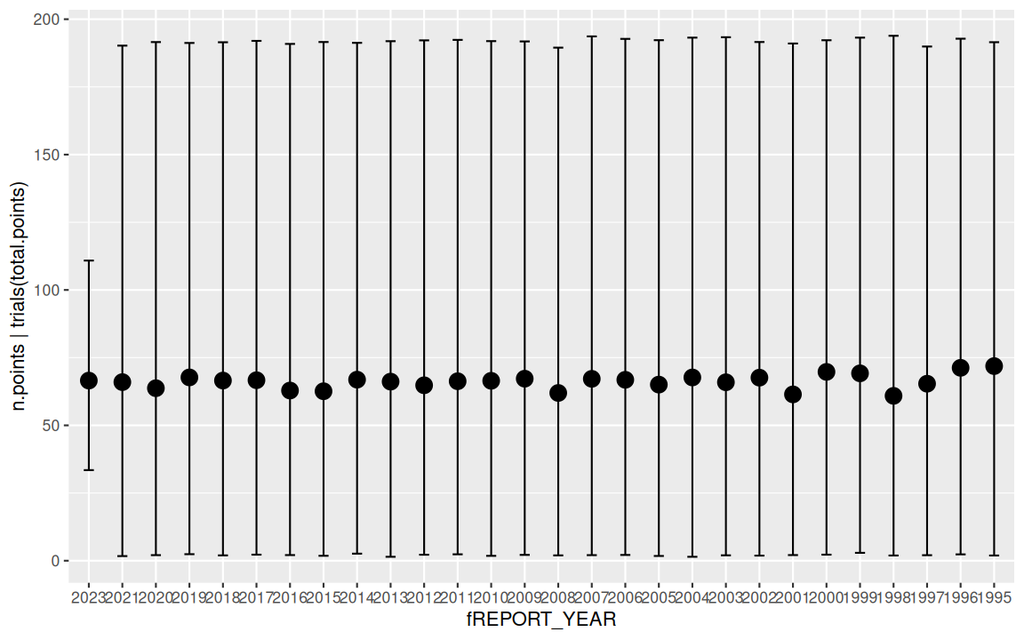

```r
ltmp_sub.brm2 |>
  conditional_effects(conditions = data.frame(total.points = 200)) |>
  plot()
```

The above seem sufficiently wide whilst at the same time not providing any encouragement for the sampler to wander off into very unsupported areas.

The following takes approx 500 seconds

```r
ltmp_sub.brm3 <- update(ltmp_sub.brm2,
  sample_prior = "yes",
  chains = 3, cores = 3,
  control = list(adapt_delta = 0.99, max_treedepth = 20),
  thin = 10, iter = 10000, warmup = 5000,
  refresh = 100
)
```

```
The desired updates require recompiling the model
```

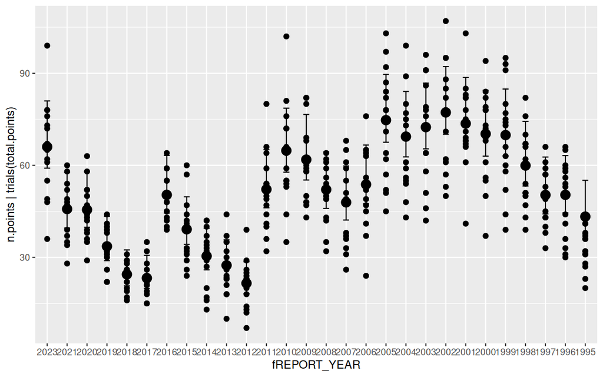

```r
ltmp_sub.brm3 |>
  conditional_effects(conditions = data.frame(total.points = 200)) |>
  plot(points = TRUE)
```

**Plotting prior and posterior**

```r
ltmp_sub.brm3 |> get_variables()
```

```
 [1] "b_Intercept"
 [2] "b_fREPORT_YEAR2021"
 [3] "b_fREPORT_YEAR2020"
 [4] "b_fREPORT_YEAR2019"
 [5] "b_fREPORT_YEAR2018"
 [6] "b_fREPORT_YEAR2017"
 [7] "b_fREPORT_YEAR2016"
 [8] "b_fREPORT_YEAR2015"
 [9] "b_fREPORT_YEAR2014"
[10] "b_fREPORT_YEAR2013"
[11] "b_fREPORT_YEAR2012"
[12] "b_fREPORT_YEAR2011"
[13] "b_fREPORT_YEAR2010"
[14] "b_fREPORT_YEAR2009"
[15] "b_fREPORT_YEAR2008"
```

[output cut: 46 more lines]

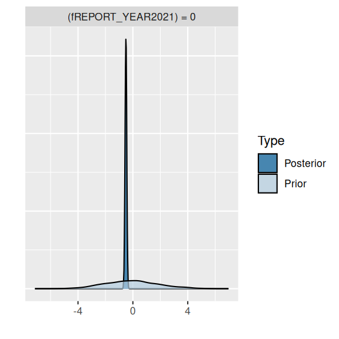

```r
ltmp_sub.brm3 |>
  hypothesis("fREPORT_YEAR2021=0") %>%
  plot()
```

```r
## ltmp_sub.brm3 %>% SUYR_prior_and_posterior()
```

# 9 MCMC sampling diagnostics

**brms**

**bayesplot**

The `bayesplot` package offers a range of MCMC diagnostics as well as Posterior Probability Checks (PPC), all of which have a convenient `plot()` interface. Lets start with the MCMC diagnostics.

**See list of available diagnostics by name**

```r
available_mcmc()
```

```
bayesplot MCMC module:
  mcmc_acf
  mcmc_acf_bar
  mcmc_areas
  mcmc_areas_ridges
  mcmc_combo
  mcmc_dens
  mcmc_dens_chains
  mcmc_dens_overlay
  mcmc_hex
  mcmc_hist
  mcmc_hist_by_chain
  mcmc_intervals
  mcmc_neff
  mcmc_neff_hist
  mcmc_nuts_acceptance
  mcmc_nuts_divergence
  mcmc_nuts_energy
  mcmc_nuts_stepsize
  mcmc_nuts_treedepth
  mcmc_pairs
  mcmc_parcoord
  mcmc_rank_ecdf
  mcmc_rank_hist
  mcmc_rank_overlay
  mcmc_recover_hist
  mcmc_recover_intervals
  mcmc_recover_scatter
  mcmc_rhat
  mcmc_rhat_hist
  mcmc_scatter
  mcmc_trace
  mcmc_trace_highlight
  mcmc_violin
```

Of these, we will focus on:

- trace: this plots the estimates of each parameter over the post-warmup length of each MCMC chain. Each chain is plotted in a different shade of blue, with each parameter in its own facet. Ideally, each **trace** should just look like noise without any discernible drift and each of the traces for a specific parameter should look the same (i.e, should not be displaced above or below any other trace for that parameter).

```r
pars <- ltmp_sub.brm3 |>
  get_variables() |>
  str_subset("^b_.*|^sd.*")
pars
```

```
 [1] "b_Intercept"                      "b_fREPORT_YEAR2021"
 [3] "b_fREPORT_YEAR2020"               "b_fREPORT_YEAR2019"
 [5] "b_fREPORT_YEAR2018"               "b_fREPORT_YEAR2017"
 [7] "b_fREPORT_YEAR2016"               "b_fREPORT_YEAR2015"
 [9] "b_fREPORT_YEAR2014"               "b_fREPORT_YEAR2013"
[11] "b_fREPORT_YEAR2012"               "b_fREPORT_YEAR2011"
[13] "b_fREPORT_YEAR2010"               "b_fREPORT_YEAR2009"
[15] "b_fREPORT_YEAR2008"               "b_fREPORT_YEAR2007"
[17] "b_fREPORT_YEAR2006"               "b_fREPORT_YEAR2005"
[19] "b_fREPORT_YEAR2004"               "b_fREPORT_YEAR2003"
[21] "b_fREPORT_YEAR2002"               "b_fREPORT_YEAR2001"
[23] "b_fREPORT_YEAR2000"               "b_fREPORT_YEAR1999"
[25] "b_fREPORT_YEAR1998"               "b_fREPORT_YEAR1997"
[27] "b_fREPORT_YEAR1996"               "b_fREPORT_YEAR1995"
[29] "sd_REEF_SITE__Intercept"          "sd_REEF_SITE_TRANSECT__Intercept"
```

[figure not shown]

```r
ltmp_sub.brm3 |> mcmc_plot(type = "trace", variable = pars)
```

The chains appear well mixed and very similar

- acf_bar (autocorrelation function): plots the autocorrelation between successive MCMC sample lags for each parameter and each chain

[figure not shown]

```r
ltmp_sub.brm3 |> mcmc_plot(type = "acf_bar", variable = pars)
```

There is no evidence of auto-correlation in the MCMC samples

- rhat_hist: Rhat is a **scale reduction factor** measure of convergence between the chains. The closer the values are to 1, the more the chains have converged. Values greater than 1.05 indicate a lack of convergence. There will be an Rhat value for each parameter estimated.

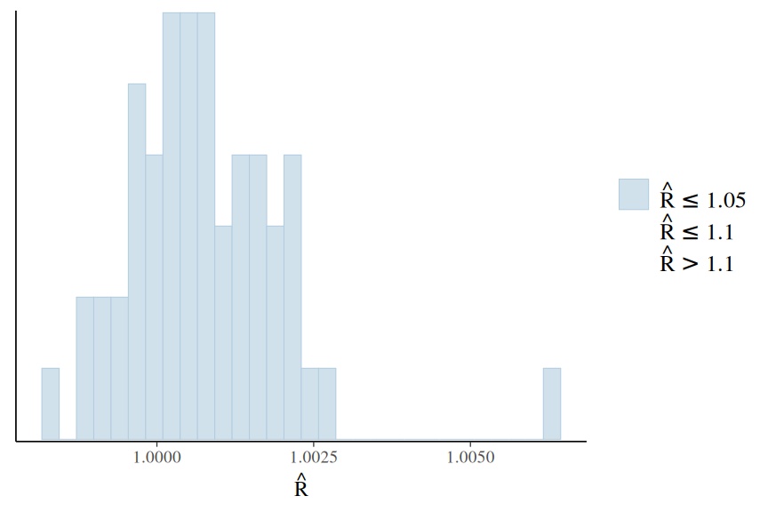

```r
ltmp_sub.brm3 |> mcmc_plot(type = "rhat_hist")
```

All Rhat values are below 1.05, suggesting the chains have converged.

- neff_hist (number of effective samples): the ratio of the number of effective samples (those not rejected by the sampler) to the number of samples provides an indication of the effectiveness (and efficiency) of the MCMC sampler. Ratios that are less than 0.5 for a parameter suggest that the sampler spent considerable time in difficult areas of the sampling domain and rejected more than half of the samples (replacing them with the previous effective sample).

  If the ratios are low, tightening the priors may help.

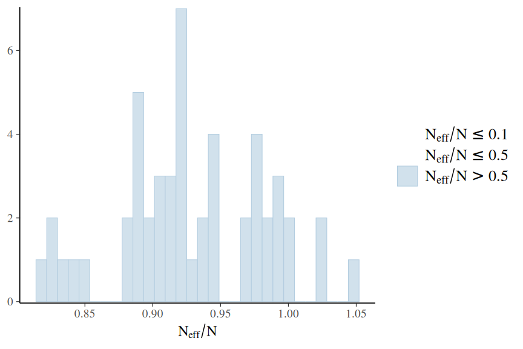

```r
ltmp_sub.brm2 |> mcmc_plot(type = "neff_hist")
```

Ratios all very high.

**More diagnostics**

[figure not shown]

```r
ltmp_sub.brm3 |> mcmc_plot(type = "combo", variable = pars)
```

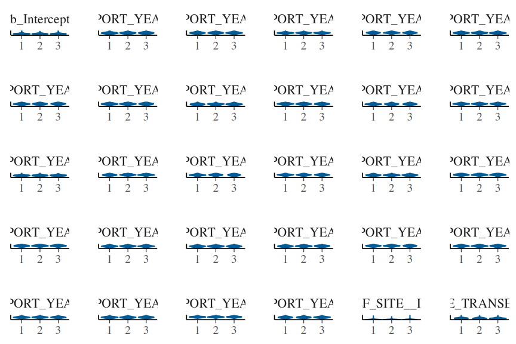

```r
ltmp_sub.brm3 |> mcmc_plot(type = "violin", variable = pars)
```

**stan plots**

The `rstan` package offers a range of MCMC diagnostics. Lets start with the MCMC diagnostics.

Of these, we will focus on:

- stan_trace: this plots the estimates of each parameter over the post-warmup length of each MCMC chain. Each chain is plotted in a different colour, with each parameter in its own facet. Ideally, each **trace** should just look like noise without any discernible drift and each of the traces for a specific parameter should look the same (i.e, should not be displaced above or below any other trace for that parameter).

```r
pars <- ltmp_sub.brm3 |>
  get_variables() |>
  str_subset("^b_.*|^sd.*")
pars
```

```
 [1] "b_Intercept"                      "b_fREPORT_YEAR2021"
 [3] "b_fREPORT_YEAR2020"               "b_fREPORT_YEAR2019"
 [5] "b_fREPORT_YEAR2018"               "b_fREPORT_YEAR2017"
 [7] "b_fREPORT_YEAR2016"               "b_fREPORT_YEAR2015"
 [9] "b_fREPORT_YEAR2014"               "b_fREPORT_YEAR2013"
[11] "b_fREPORT_YEAR2012"               "b_fREPORT_YEAR2011"
[13] "b_fREPORT_YEAR2010"               "b_fREPORT_YEAR2009"
[15] "b_fREPORT_YEAR2008"               "b_fREPORT_YEAR2007"
[17] "b_fREPORT_YEAR2006"               "b_fREPORT_YEAR2005"
[19] "b_fREPORT_YEAR2004"               "b_fREPORT_YEAR2003"
[21] "b_fREPORT_YEAR2002"               "b_fREPORT_YEAR2001"
[23] "b_fREPORT_YEAR2000"               "b_fREPORT_YEAR1999"
[25] "b_fREPORT_YEAR1998"               "b_fREPORT_YEAR1997"
[27] "b_fREPORT_YEAR1996"               "b_fREPORT_YEAR1995"
[29] "sd_REEF_SITE__Intercept"          "sd_REEF_SITE_TRANSECT__Intercept"
```

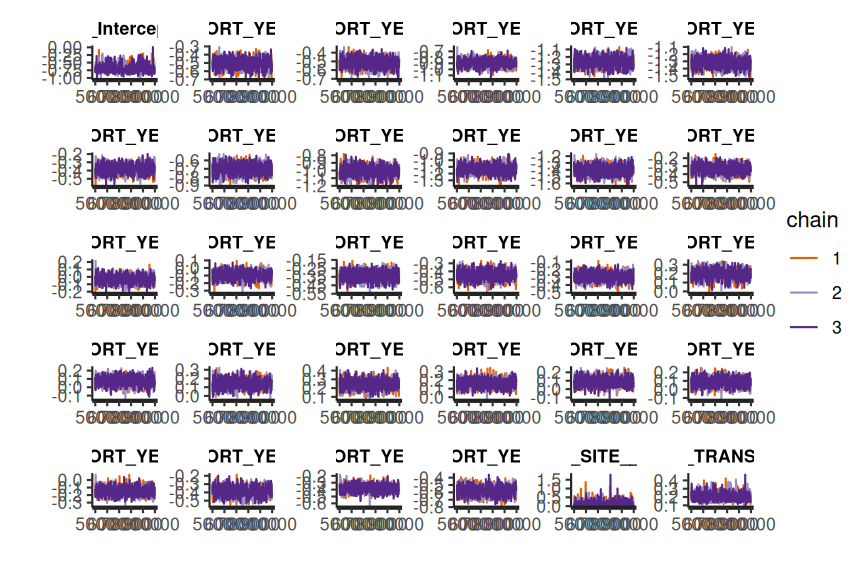

```r
ltmp_sub.brm3$fit |>
  stan_trace(pars = pars)
```

The chains appear well mixed and very similar

- stan_acf (auto-correlation function): plots the auto-correlation between successive MCMC sample lags for each parameter and each chain

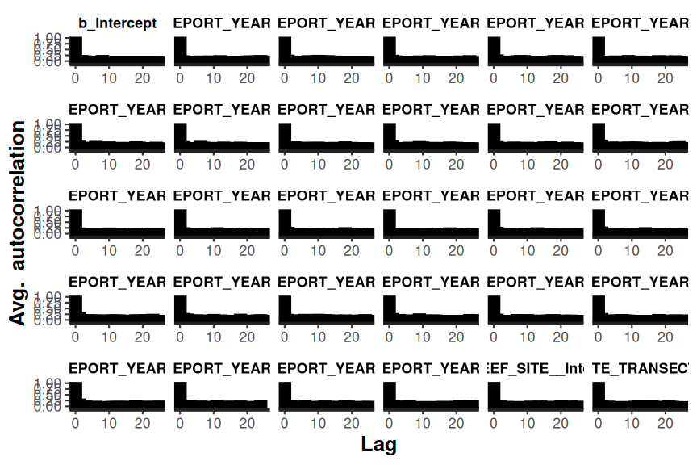

```r
ltmp_sub.brm3$fit |>
  stan_ac(pars = pars)
```

There is no evidence of auto-correlation in the MCMC samples

- stan_rhat: Rhat is a **scale reduction factor** measure of convergence between the chains. The closer the values are to 1, the more the chains have converged. Values greater than 1.05 indicate a lack of convergence. There will be an Rhat value for each parameter estimated.

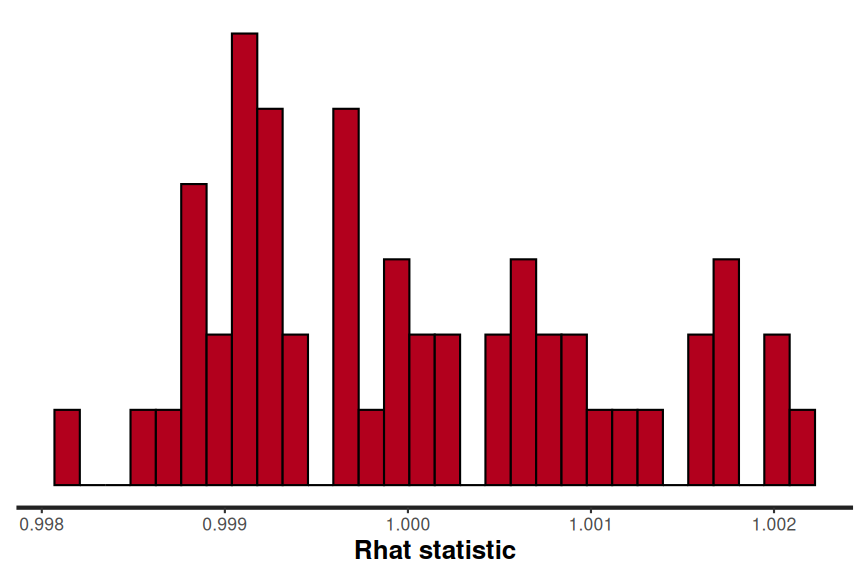

```r
ltmp_sub.brm3$fit |> stan_rhat()
```

All Rhat values are below 1.05, suggesting the chains have converged.

- stan_ess (number of effective samples): the ratio of the number of effective samples (those not rejected by the sampler) to the number of samples provides an indication of the effectiveness (and efficiency) of the MCMC sampler. Ratios that are less than 0.5 for a parameter suggest that the sampler spent considerable time in difficult areas of the sampling domain and rejected more than half of the samples (replacing them with the previous effective sample).

  If the ratios are low, tightening the priors may help.

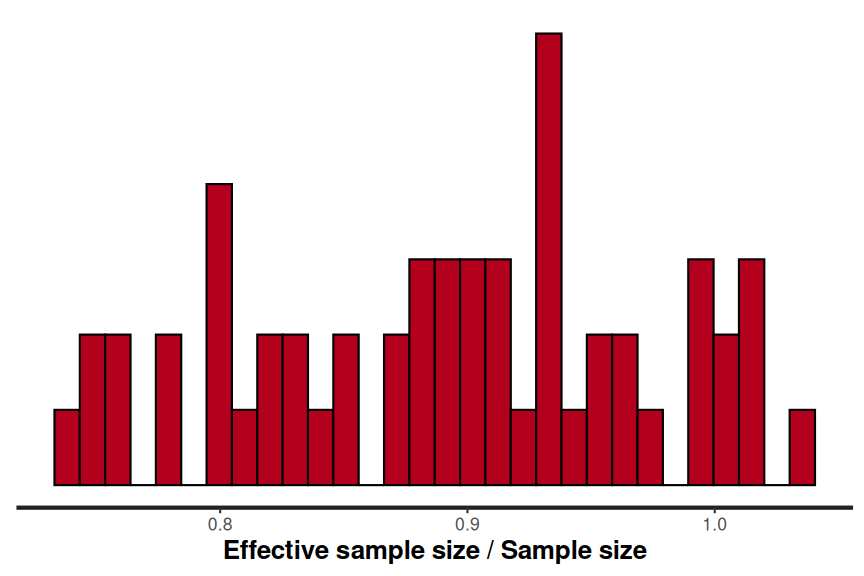

```r
ltmp_sub.brm3$fit |> stan_ess()
```

Ratios all very high.

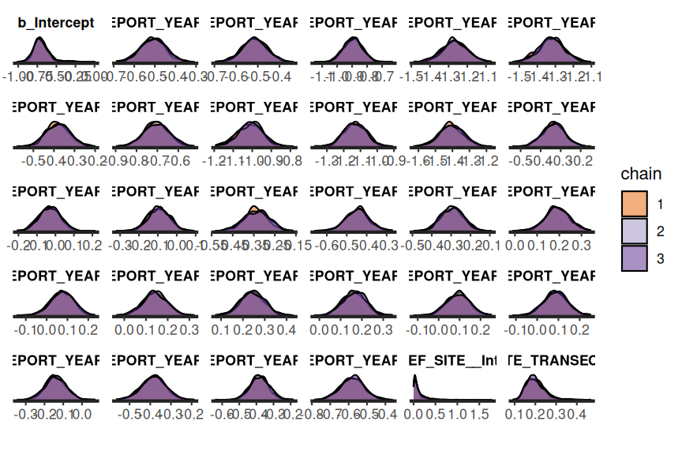

```r
ltmp_sub.brm3$fit |>
  stan_dens(separate_chains = TRUE, pars = pars)
```